# PML - Course Project

Ruben Adad

13 de abril de 2015

# Introduction

Using devices such as Jawbone Up, Nike FuelBand, and Fitbit it is now possible to collect a large amount of data about personal activity relatively inexpensively. In this project, our goal is to use data from accelerometers on the belt, forearm, arm, and dumbell of 6 participants. They were asked to perform barbell lifts correctly and incorrectly in 5 different ways. The response variable (“classe”) is a factor with labels A, B, C, D, E with the following meanings:

- exactly according to the specification (Class A)
- throwing the elbows to the front (Class B)
- lifting the dumbbell only halfway (Class C)
- lowering the dumbbell only halfway (Class D)
- throwing the hips to the front (Class E)

Velloso, E.; Bulling, A.; Gellersen, H.; Ugulino, W.; Fuks, H. Qualitative Activity Recognition of Weight Lifting Exercises. Proceedings of 4th International Conference in Cooperation with SIGCHI (Augmented Human ’13) . Stuttgart, Germany: ACM SIGCHI, 2013.

The results of these measurements were collected in a dataset with 160 variables and 19,622 observations. We will use this data to build a predictive model capable of determine how well the exercise was performed (variable “classe”). There is a second dataset with 20 observations (without the response variable) that we will use to apply our model to predict the class.

Step 1 - read the data.

```r
setwd("~/Documents/CURSOS/Practical Machine Learning/Quizzes")
library(caret)
train <- read.csv("pml-training.csv", na.strings=c("","NA","#DIV/0!"))
test <- read.csv("pml-testing.csv", na.strings=c("","NA","#DIV/0!"))
```

# Pre-Processing

After a brief exploratory analysis I discovered that there are many missing values, so I will exclude those columns having more than 10% of missing values. I will also exclude columns with an absolute correlation factor greater than 0.9. Finally I will exclude the first 7 columns of the data since these are attributes with irrelevant data for prediction purposes. This will leave 45 predictor variables and the response variable (“classe”). Then I split the data to build the training and testing data for our model.

```r
dim(train)
```

```
## [1] 19622   160
```

```r
na_count <- apply(train, 2, function(x) sum(is.na(x)))
cols <- names(which(na_count/dim(train[1]) < 0.10, arr.ind=T))
train_new <- train[, cols]
train_new <- train_new[, -(1:7)]
train_Cor <-  cor(subset(train_new, select = -classe))
highCorr <- findCorrelation(train_Cor, cutoff = 0.9)
train_new <- train_new[, -highCorr]
dim(train_new)
```

```
## [1] 19622    46
```

```r
inTrain = createDataPartition(train_new$classe, p = 3/4)[[1]]
trn <- train_new[inTrain,]
tst <- train_new[-inTrain,]
dim(trn)
```

```
## [1] 14718    46
```

```r
dim(tst)
```

```
## [1] 4904   46
```

# Variable selection

In this section I will build a model using “random forest” to select the 20 most important predictor variables in order to have a more simple model to work with. I compared the accuracy of this model (0.9918) with 45 predictors against a model using random forest with 20 predictors and the difference is marginal.

To speed up model building I am using the doMC package to run with 6 parallel tasks.

```r
library(doMC)
registerDoMC(cores = 6)
model_rf <- train(classe ~ . , data=trn, method = "rf")
```

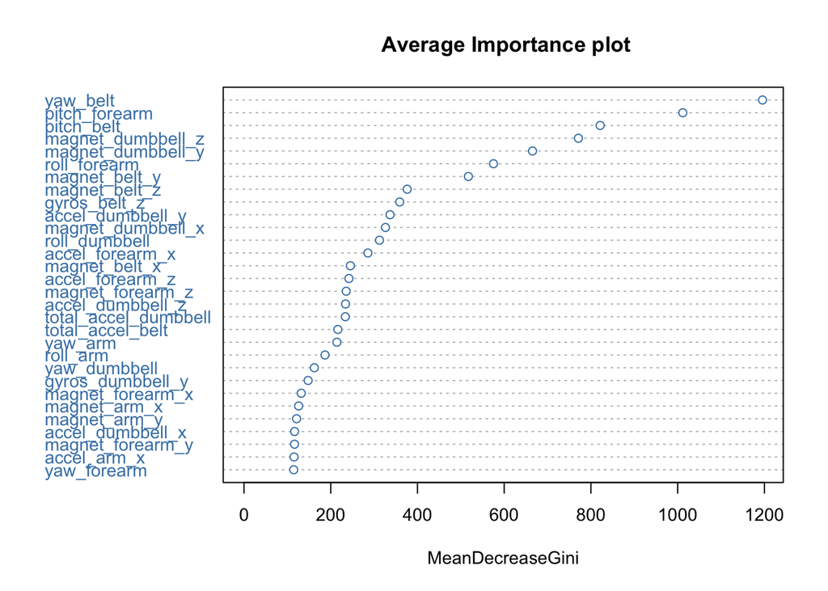

```r
varImpPlot(model_rf$finalModel, main=" Average Importance plot", col = "steelblue", cex = 0.9)
```

```r
top20 <- varImp(model_rf)[[1]]
x <- order(-top20$Overall)
top20vars <- row.names(top20)[x][1:20]
trn20 <- cbind(trn[,top20vars], trn$classe)
names(trn20)[21] <- "classe"
```

# Training

```r
train_gbm <- train(classe ~ . , data=trn20, method = "gbm", verbose=F)
pred_gbm <- predict(train_gbm, newdata=tst)
confusionMatrix(pred_gbm, tst$classe)
```

```
## Confusion Matrix and Statistics
##
##           Reference
## Prediction    A    B    C    D    E
##          A 1374   36    0    3    0
##          B   13  864   34    5   11
##          C    5   37  808   35    4
##          D    3    6   12  753   13
##          E    0    6    1    8  873
##
## Overall Statistics
##
##                Accuracy : 0.9527
##                  95% CI : (0.9464, 0.9585)
##     No Information Rate : 0.2845
##     P-Value [Acc > NIR] : < 2.2e-16
##
##                   Kappa : 0.9401
##  Mcnemar's Test P-Value : NA
##
## Statistics by Class:
##
##                      Class: A Class: B Class: C Class: D Class: E
## Sensitivity            0.9849   0.9104   0.9450   0.9366   0.9689
## Specificity            0.9889   0.9841   0.9800   0.9917   0.9963
## Pos Pred Value         0.9724   0.9320   0.9089   0.9568   0.9831
## Neg Pred Value         0.9940   0.9786   0.9883   0.9876   0.9930
## Prevalence             0.2845   0.1935   0.1743   0.1639   0.1837
## Detection Rate         0.2802   0.1762   0.1648   0.1535   0.1780
## Detection Prevalence   0.2881   0.1890   0.1813   0.1605   0.1811
## Balanced Accuracy      0.9869   0.9473   0.9625   0.9641   0.9826
```

```r
train_rf <- train(classe ~ . , data=trn20, method = "rf")
pred_rf <- predict(train_rf, newdata=tst)
confusionMatrix(pred_rf, tst$classe)
```

```
## Confusion Matrix and Statistics
##
##           Reference
## Prediction    A    B    C    D    E
##          A 1395    8    0    0    0
##          B    0  929    9    0    0
##          C    0   10  842    4    1
##          D    0    2    4  799    3
##          E    0    0    0    1  897
##
## Overall Statistics
##
##                Accuracy : 0.9914
##                  95% CI : (0.9884, 0.9938)
##     No Information Rate : 0.2845
##     P-Value [Acc > NIR] : < 2.2e-16
##
##                   Kappa : 0.9892
##  Mcnemar's Test P-Value : NA
##
## Statistics by Class:
##
##                      Class: A Class: B Class: C Class: D Class: E
## Sensitivity            1.0000   0.9789   0.9848   0.9938   0.9956
## Specificity            0.9977   0.9977   0.9963   0.9978   0.9998
## Pos Pred Value         0.9943   0.9904   0.9825   0.9889   0.9989
## Neg Pred Value         1.0000   0.9950   0.9968   0.9988   0.9990
## Prevalence             0.2845   0.1935   0.1743   0.1639   0.1837
## Detection Rate         0.2845   0.1894   0.1717   0.1629   0.1829
## Detection Prevalence   0.2861   0.1913   0.1748   0.1648   0.1831
## Balanced Accuracy      0.9989   0.9883   0.9905   0.9958   0.9977
```

# Combining the models

Finally, we combined both models fitting a model that combine the predictors using the training data. Then we measure the accuracy of this combined model using the test data: * combined accuracy: 0.9914

```r
pred_gbm <- predict(train_gbm, newdata=trn)
pred_rf <- predict(train_rf, newdata=trn)
trn_dat_comb <- data.frame(GBM = pred_gbm, RF = pred_rf, classe = trn$classe)
train_comb <- train(classe ~ ., method="rf", data=trn_dat_comb)
pred_gbm <- predict(train_gbm, newdata=tst)
pred_rf <- predict(train_rf, newdata=tst)
tst_dat_comb <- data.frame(GBM = pred_gbm, RF = pred_rf, classe = tst$classe)
pred_comb <- predict(train_comb, newdata=tst_dat_comb)
confusionMatrix(pred_comb, tst$classe)
```

```
## Confusion Matrix and Statistics
##
##           Reference
## Prediction    A    B    C    D    E
##          A 1395    8    0    0    0
##          B    0  929    9    0    0
##          C    0   10  842    4    1
##          D    0    2    4  799    3
##          E    0    0    0    1  897
##
## Overall Statistics
##
##                Accuracy : 0.9914
##                  95% CI : (0.9884, 0.9938)
##     No Information Rate : 0.2845
##     P-Value [Acc > NIR] : < 2.2e-16
##
##                   Kappa : 0.9892
##  Mcnemar's Test P-Value : NA
##
## Statistics by Class:
##
##                      Class: A Class: B Class: C Class: D Class: E
## Sensitivity            1.0000   0.9789   0.9848   0.9938   0.9956
## Specificity            0.9977   0.9977   0.9963   0.9978   0.9998
## Pos Pred Value         0.9943   0.9904   0.9825   0.9889   0.9989
## Neg Pred Value         1.0000   0.9950   0.9968   0.9988   0.9990
## Prevalence             0.2845   0.1935   0.1743   0.1639   0.1837
## Detection Rate         0.2845   0.1894   0.1717   0.1629   0.1829
## Detection Prevalence   0.2861   0.1913   0.1748   0.1648   0.1831
## Balanced Accuracy      0.9989   0.9883   0.9905   0.9958   0.9977
```

# Conclusions

Since the combined model has the same accuracy as the random forest we will choose the random forest model since it is simpler than the combined model.

```r
head(getTree(train_rf$finalModel, k=1, labelVar=T))
```

```
##   left daughter right daughter         split var split point status
## 1             2              3     pitch_forearm      -26.45      1
## 2             4              5  magnet_forearm_z      800.50      1
## 3             6              7 magnet_dumbbell_y      436.50      1
## 4             8              9 magnet_dumbbell_x     -563.50      1
## 5            10             11   accel_forearm_x      217.00      1
## 6            12             13      roll_forearm      121.50      1
##   prediction
## 1       <NA>
## 2       <NA>
## 3       <NA>
## 4       <NA>
## 5       <NA>
## 6       <NA>
```

```r
head(getTree(train_rf$finalModel, k=2, labelVar=T))
```

```
##   left daughter right daughter         split var split point status
## 1             2              3     magnet_belt_y     555.500      1
## 2             4              5  magnet_forearm_z     102.000      1
## 3             6              7      roll_forearm     116.500      1
## 4             8              9     magnet_belt_z    -460.500      1
## 5            10             11 magnet_dumbbell_z     254.500      1
## 6            12             13     pitch_forearm      -0.115      1
##   prediction
## 1       <NA>
## 2       <NA>
## 3       <NA>
## 4       <NA>
## 5       <NA>
## 6       <NA>
```

```r
library(inTrees)
treeList <- RF2List(train_rf$finalModel)
exec <- extractRules(treeList, trn20)
```

```
## 3034 rules (length<=6) were extracted from the first 100 trees.
```

```r
ruleMetric <- getRuleMetric(exec, trn20, trn20$classe)
ruleMetric <- pruneRule(ruleMetric, trn20, trn20$classe)
ruleMetric <- selectRuleRRF(ruleMetric, trn20, trn20$classe)
rules <- presentRules(ruleMetric,colnames(trn20))
head(rules)
```

```
##      len freq    err
## [1,] "3" "0.769" "0.779"
## [2,] "2" "0.078" "0"
## [3,] "4" "0.325" "0.595"
## [4,] "3" "0.031" "0.403"
## [5,] "3" "0.069" "0.015"
## [6,] "6" "0.055" "0.112"
##      condition
## [1,] "yaw_belt<=169.5 & pitch_forearm>-26.55 & magnet_dumbbell_z>-91.5"
## [2,] "yaw_belt>15.425 & yaw_belt<=153"
## [3,] "pitch_forearm>-26.6 & pitch_belt>-42.45 & magnet_dumbbell_z>-23.5 & magnet_dumbbell_x<=-448.5"
## [4,] "magnet_dumbbell_z<=-94.5 & magnet_dumbbell_x>-454.5 & magnet_dumbbell_x<=488.5"
## [5,] "pitch_belt<=25.65 & magnet_belt_z<=-382.5 & accel_forearm_z<=100.5"
## [6,] "magnet_dumbbell_y>436.5 & magnet_belt_y>556.5 & magnet_belt_z<=-288.5 & gyros_belt_z>-0.255 & total_accel_dumbbell>5.5 & total_accel_dumbbell<=26.5"
##      pred impRRF
## [1,] "C"  "1"
## [2,] "E"  "0.419182815198148"
## [3,] "C"  "0.379891013604081"
## [4,] "B"  "0.309172785443487"
## [5,] "E"  "0.237505463878844"
## [6,] "B"  "0.174487641860336"
```